# 7.0 Compare Seasonal Minimum and 10th Percentile

J Hagy

2024-09-04

This program evaluates the relationship between values of the 10th percentile and values of the seasonal minimum POSAT, generating Figure 10 in the TSD for the final rule.

## Calculate the annual minimums

Add the minimum to the percentiles, using percentile=0. Do this for both the observed DO and restored DO.

```r
df <- rbind(drc_summer %>% mutate(Site="Chester"),
            drpl_summer %>% mutate(Site="Penn's Landing")) %>%
  filter(between(month(date),7,10))

mins <- df %>% group_by(Site,year) %>%
  summarize(posat=min(posat.mean),
            do=min(do.mgL.mean)) %>%
  ungroup() %>%
  mutate(type="Observed",percentile=0) %>%
  select(type,Site,year,do,posat,percentile)
mins.res <- restoredWQ %>%
  filter(between(month(date),7,10)) %>%
  group_by(Site,year) %>%
  summarize(posat=min(posat.mean),
            do=min(do.mean)) %>%
  ungroup() %>%
  mutate(type="Restored",percentile=0) %>%
  select(type,Site,year,do,posat,percentile)
df <- rbind(percentiles,mins,mins.res)
```

## Graph minimum vs. 10th percentile

Include predicted minimum when then 10th percentile POSAT is 66%

```r
df.pivot <- df %>%
  mutate(percentile=percentile*100) %>%
  select(type,Site,year,posat,percentile) %>%
  pivot_wider(names_from = percentile,names_prefix = "P.",
              values_from = posat)

fit <- lm(P.0 ~ P.10,data=df.pivot)
summary(fit)
```

```
##
## Call:
## lm(formula = P.0 ~ P.10, data = df.pivot)
##
## Residuals:
##     Min      1Q  Median      3Q     Max
## -7.4388 -1.1853  0.1899  2.0615  3.9582
##
## Coefficients:
##              Estimate Std. Error t value Pr(>|t|)
## (Intercept) -11.38919    2.17444  -5.238 1.29e-06 ***
## P.10          1.09957    0.03265  33.681  < 2e-16 ***
## ---
## Signif. codes:  0 '***' 0.001 '**' 0.01 '*' 0.05 '.' 0.1 ' ' 1
##
## Residual standard error: 2.503 on 80 degrees of freedom
## Multiple R-squared:  0.9341, Adjusted R-squared:  0.9333
## F-statistic:  1134 on 1 and 80 DF,  p-value: < 2.2e-16
```

```r
tmp <- predict(fit,data.frame(P.10=66),se.fit=TRUE)
tmp
```

```
## $fit
##        1
## 61.18221
##
## $se.fit
## [1] 0.2764589
##
## $df
## [1] 80
##
## $residual.scale
## [1] 2.503367
```

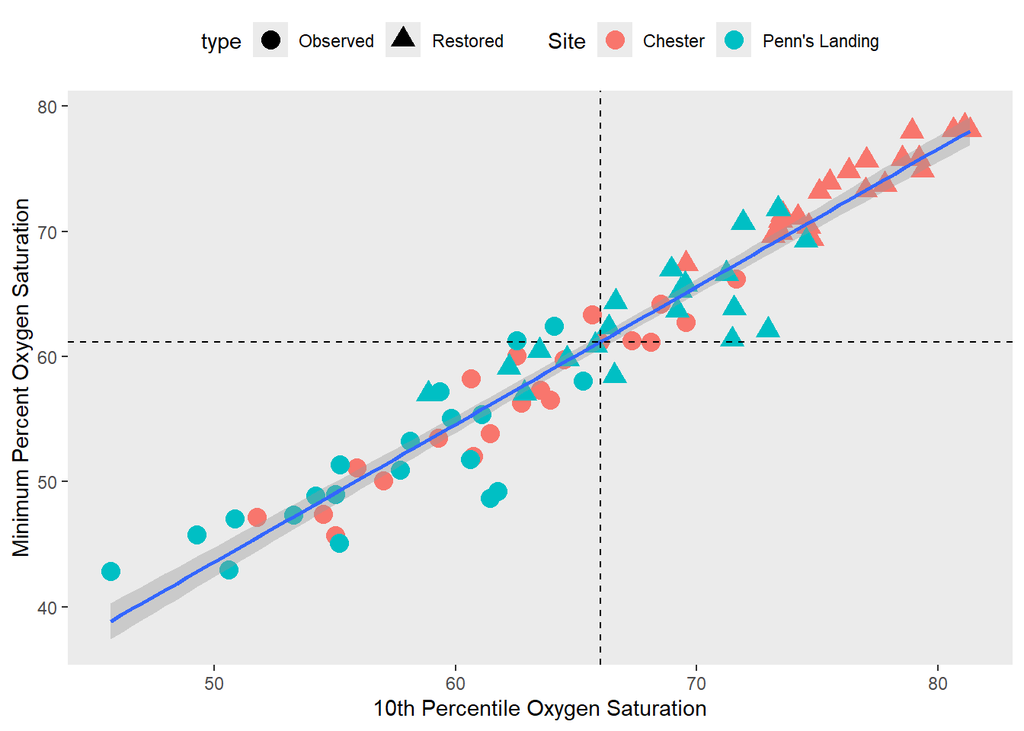

```r
minCI <- tmp$fit+qnorm(c(0.025,0.975),0,tmp$se.fit)

plt <- ggplot() +
  geom_point(data=df.pivot,aes(x=P.10,y=P.0,color=Site,shape=type),size=4)+
  geom_smooth(data=df.pivot,aes(x=P.10,y=P.0),method="lm")+
  geom_vline(xintercept = 66,linetype=2)+
  geom_hline(yintercept=tmp$fit,linetype=2)+
  theme(panel.grid=element_blank(),
        legend.position="top")+
  labs(x="10th Percentile Oxygen Saturation",y="Minimum Percent Oxygen Saturation")
plt
```

# Expected minimum DO values

If the minimum 10th percentile POSAT of 66% is to be attained in the Juvenile Development season in every year, then the 10th percentile will likely be higher than 66% in most or all years.

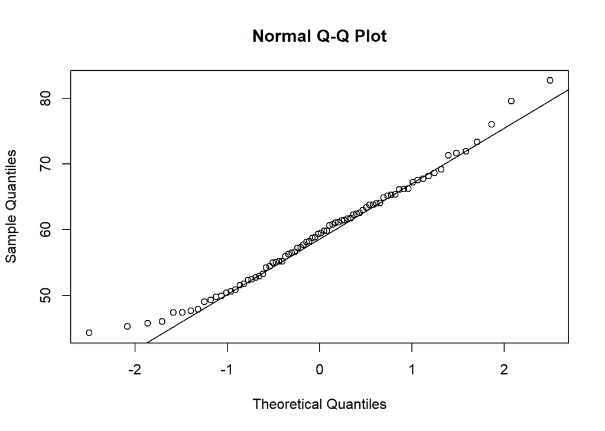

```r
tmp <- percentiles %>%
  filter(Site=="Penn's Landing") %>%
  filter(type=="Observed")
qqnorm(tmp$posat)
qqline(tmp$posat)
```

```r
tmp <- df %>%
  filter(percentile==0.1) %>%
  group_by(Site,type) %>%
  summarize(sd=sd(posat))
tmp
```

```
## # A tibble: 4 × 3
## # Groups:   Site [2]
##   Site           type        sd
##   <chr>          <chr>    <dbl>
## 1 Chester        Observed  5.38
## 2 Chester        Restored  3.08
## 3 Penn's Landing Observed  5.31
## 4 Penn's Landing Restored  4.22
```

What is the mean POSAT 10th percentile if 5% of 10th percentiles will be less than 66%?

```r
# t-statistic with 5% of distribution below.
qt(0.05,20)
```

```
## [1] -1.724718
```

```r
tmp <- tmp %>%
  mutate(meanP10=66-qt(0.05,20)*sd)
tmp
```

```
## # A tibble: 4 × 4
## # Groups:   Site [2]
##   Site           type        sd meanP10
##   <chr>          <chr>    <dbl>   <dbl>
## 1 Chester        Observed  5.38    75.3
## 2 Chester        Restored  3.08    71.3
## 3 Penn's Landing Observed  5.31    75.1
## 4 Penn's Landing Restored  4.22    73.3
```

If the mean P.10 of POSAT is as calculated, what is the mean value for the minimum POSAT?

```r
meanP0 <- predict(fit,data.frame(P.10=tmp$meanP10))

tmp <- tmp %>%
  ungroup() %>%
  mutate(meanP.0=meanP0)
tmp
```

```
## # A tibble: 4 × 5
##   Site           type        sd meanP10 meanP.0
##   <chr>          <chr>    <dbl>   <dbl>   <dbl>
## 1 Chester        Observed  5.38    75.3    71.4
## 2 Chester        Restored  3.08    71.3    67.0
## 3 Penn's Landing Observed  5.31    75.1    71.2
## 4 Penn's Landing Restored  4.22    73.3    69.2
```

## Make a graph for TSD for the final rule

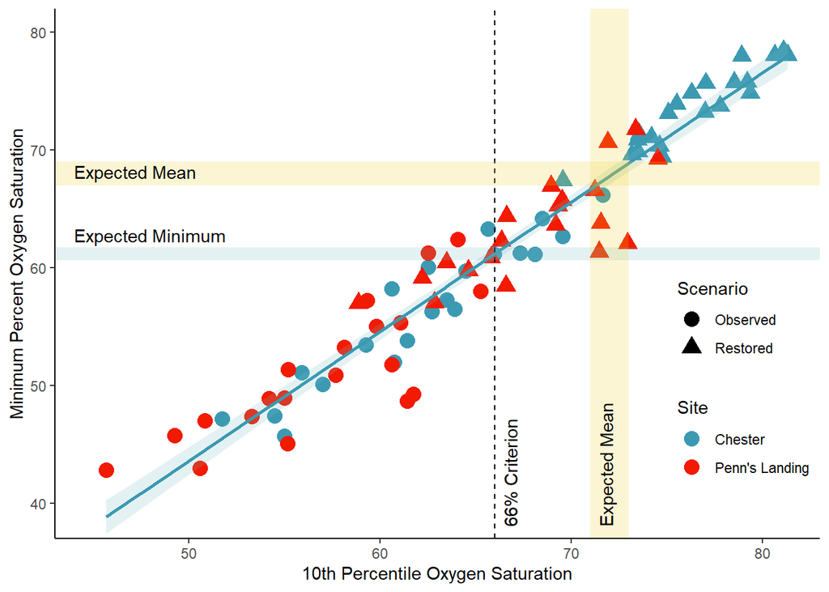

```r
plt <- ggplot() +
  geom_point(data=df.pivot,aes(x=P.10,y=P.0,color=Site,shape=type),size=4)+
  geom_smooth(data=df.pivot,aes(x=P.10,y=P.0),method="lm",fill=pal[2],alpha=0.2,color=pal[1])+
  # add vline for criterion
  geom_vline(xintercept = 66,linetype=2)+
  # draw confidence limit for prediction of minimum at P.10=66%
  geom_rect(aes(ymin=minCI[1],ymax=minCI[2],xmin=43,xmax=83),fill=pal[2],alpha=0.2)+
  geom_hline(yintercept=tmp$fit,linetype=2)+
  # draw
  geom_rect(aes(ymin=37,ymax=82,xmin=71,xmax=73),fill=pal[3],alpha=0.2)+
  geom_rect(aes(ymin=67,ymax=69,xmin=43,xmax=83),fill=pal[3],alpha=0.2)+

  theme(panel.grid=element_blank(),
        legend.position="top")+
  labs(x="10th Percentile Oxygen Saturation",y="Minimum Percent Oxygen Saturation",
       shape="Scenario")+
  scale_x_continuous(limits=c(43,83),expand=c(0,0))+
  scale_y_continuous(limits=c(37,82),expand=c(0,0))+
  scale_color_manual(values=pal[c(1,5)])
plt2 <- plt+
  annotate("text",x=44,y=68.2,hjust=0,label="Expected Mean")+
  annotate("text",x=71.8,y=38,hjust=0,angle=90,label="Expected Mean")+
  annotate("text",x=66.8,y=38,hjust=0,angle=90,label="66% Criterion")+
  annotate("text",x=44,y=62.8,hjust=0,label="Expected Minimum")+
  theme_classic()+
  theme(legend.position="inside",legend.position.inside=c(0.9,0.3))
plt2
```

```r
pdf(file=here("figures","7.04 Expected Minimums Graph.pdf"),width=6,height=4,paper="letter")
  plt2
dev.off()
```

```r
# Figure XX.  The relationship between the 10th percentile and minimum percent
# oxygen saturation during the Juvenile Development season at Chester and Penn’s
# Landing for observed values (2002-2022) and the restored scenario. A colored
# band (blue) shows the expected minimum percent oxygen saturation (with 95%
# confidence interval) when the 10th percentile is 66%.  Yellow bands show the
# expected mean 10th percentile and minimum value if the 66% criterion value is
# attained 95% of the time and variability is as expected in the restored DO
# scenario.
```

## Make graph like Fig 10 in TSD for the final rule, but in mg/L

```r
df.pivot <- df %>%
  mutate(percentile=percentile*100) %>%
  select(type,Site,year,do,percentile) %>%
  pivot_wider(names_from = percentile,names_prefix = "P.",
              values_from = do)

 fit <- lm(P.0 ~ P.10,data=df.pivot)
 summary(fit)
```

```
##
## Call:
## lm(formula = P.0 ~ P.10, data = df.pivot)
##
## Residuals:
##     Min      1Q  Median      3Q     Max
## -0.5890 -0.1031  0.0216  0.1314  0.3287
##
## Coefficients:
##             Estimate Std. Error t value Pr(>|t|)
## (Intercept) -0.75997    0.16396  -4.635 1.37e-05 ***
## P.10         1.06425    0.03043  34.978  < 2e-16 ***
## ---
## Signif. codes:  0 '***' 0.001 '**' 0.01 '*' 0.05 '.' 0.1 ' ' 1
##
## Residual standard error: 0.1982 on 80 degrees of freedom
## Multiple R-squared:  0.9386, Adjusted R-squared:  0.9379
## F-statistic:  1223 on 1 and 80 DF,  p-value: < 2.2e-16
```

```r
 tmp <- predict(fit,data.frame(P.10=5.4),se.fit=TRUE)
 tmp
```

```
## $fit
##        1
## 4.986961
##
## $se.fit
## [1] 0.02195757
##
## $df
## [1] 80
##
## $residual.scale
## [1] 0.1981569
```

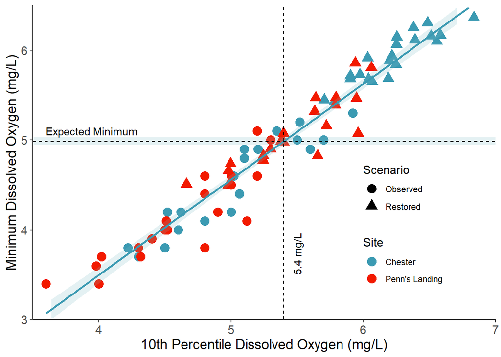

```r
 minCI <- tmp$fit+qnorm(c(0.025,0.975),0,tmp$se.fit)


plt <- ggplot() +
  geom_point(data=df.pivot,aes(x=P.10,y=P.0,color=Site,shape=type),size=4)+
  geom_smooth(data=df.pivot,aes(x=P.10,y=P.0),method="lm",fill=pal[2],alpha=0.2,color=pal[1])+
  # add vline for criterion
  geom_vline(xintercept = 5.4,linetype=2)+
  # draw confidence limit for prediction of minimum at P.10=66%
  geom_rect(aes(ymin=minCI[1],ymax=minCI[2],xmin=3.5,xmax=7),fill=pal[2],alpha=0.2)+
  geom_hline(yintercept=tmp$fit,linetype=2)+
  theme(panel.grid=element_blank(),
        legend.position="top")+
  labs(x="10th Percentile Dissolved Oxygen (mg/L)",y="Minimum Dissolved Oxygen (mg/L)",
       shape="Scenario")+
  scale_x_continuous(limits=c(3.5,7),expand=c(0,0))+
  scale_y_continuous(limits=c(3,6.5),expand=c(0,0))+
  scale_color_manual(values=pal[c(1,5)])+
  theme_classic()+
  theme(axis.text=element_text(size=12),
        axis.title=element_text(size=14),
        legend.title = element_text(size=12))+
  theme(legend.position="inside",legend.position.inside=c(0.8,0.3))+
  annotate("text",x=5.5,y=3.5,hjust=0,angle=90,label="5.4 mg/L")+
  annotate("text",x=3.6,y=5.1,hjust=0,label="Expected Minimum")
plt
```

```r
pdf(file=here("figures","7.04 10th Percentile vs Minimum DO mgL.pdf"),width=6,height=4,paper="letter")
  plt
dev.off()
```